# 第三章：数据可视化 1: ggplot2

```r
# 运行 c4a_palettes() 可以列出所有可用的色盘名称
```

- [**`rcartocolor`**](https://cran.r-project.org/web/packages/rcartocolor/readme/README.html) 推荐访问

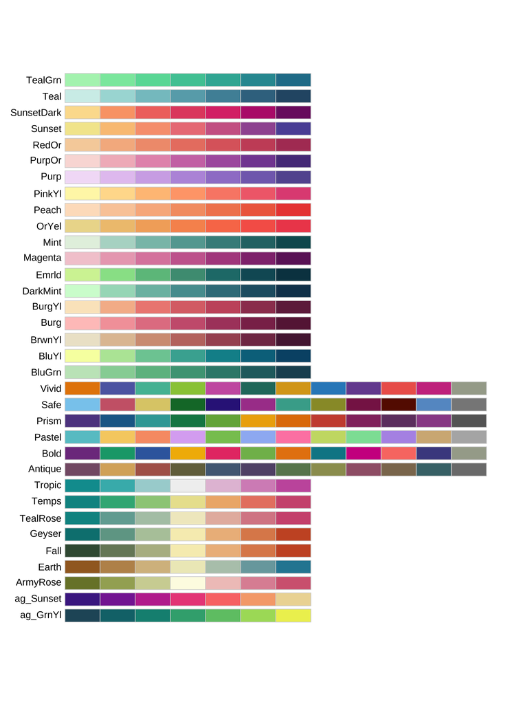

```r
# install.packages('rcartocolor')
library(rcartocolor)
display_carto_all()  #展示所有颜色
```

- [**`colorspace`**](https://cran.r-project.org/web/packages/colorspace/vignettes/colorspace.html) 推荐访问

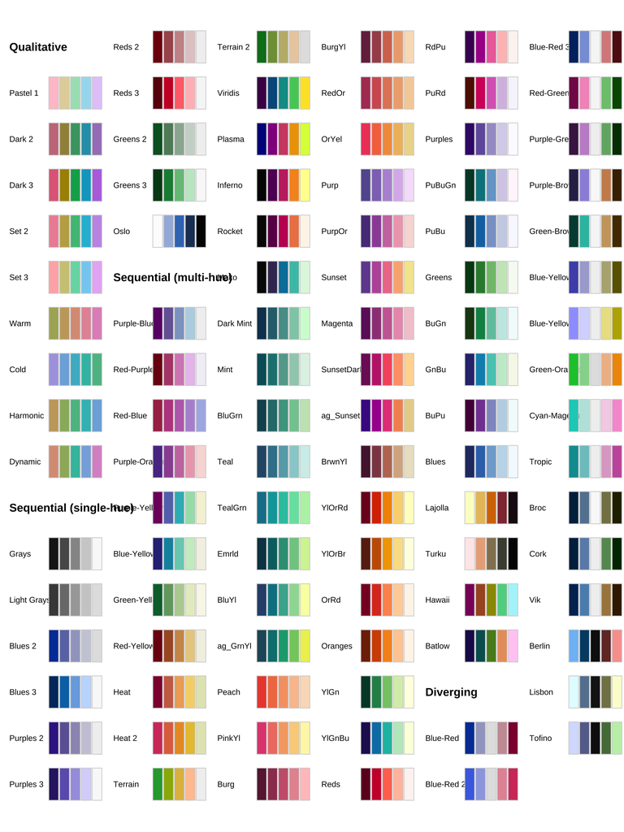

```r
# install.packages('colorspace')
library(colorspace)
hcl_palettes(plot = TRUE) #展示所有颜色
```

###### **常用配色网站（排名不分先后）**

- [**Coolors**](https://coolors.co/)
- [**Flat UI Color Picker**](https://www.flatuicolorpicker.com/)
- [**Adobe Color**](https://color.adobe.com/)
- [**ColorBrewer**](https://colorbrewer2.org/) 推荐
- [**Colormind**](http://colormind.io/)
- [**Plaetton**](http://paletton.com/)
- **Brand Color**
- [**Color Leap**](https://colorleap.app/home)
- **社交平台帖子**：小红书/知乎 等 (搜索 ‘科研论文配色’)

> 核心原则 语义正确 → 稳健可读 → 简洁克制 → 风格统一 课外参考资料：  
> - https://corytophanes.github.io/BIO_BIT_Bioinformatics_209/graphics-and-colors.html - https://www.math.pku.edu.cn/teachers/lidf/docs/Rbook/html/_Rbook/graph.html —

#### **配色灵感：从“成熟的视觉方案”借鉴**

配色并不一定需要从零开始“设计”。影视作品、海报设计与成熟的视觉系统往往已经形成了稳定的**配色结构**：以**主色**奠定基调，以**辅色**补足层次，再用少量**强调色**引导视线。对科研制图而言，这类“成熟方案”的价值主要在于帮助建立审美直觉：如何控制饱和度、如何组织冷暖关系、如何用少量对比制造重点，从而让图形在保持克制的前提下更有层次与质感。

下面给出若干影视作品的配色示例，用于观察其色彩搭配与氛围组织方式：

- **《小丑》**：

[figure not shown]

Figure 3.12. 配色灵感1

- **《安娜·卡列尼娜》**：

[figure not shown]

Figure 3.13. 配色灵感2

- **《楚门的世界》**：

[figure not shown]

Figure 3.14. 配色灵感3

- **《布达佩斯大饭店》**：

[figure not shown]

Figure 3.15. 配色灵感4

> 提醒 影视/艺术配色主要用于“审美训练与搭配借鉴”。  
> 这类配色未必天然符合科研制图规范：例如对比度不足、色觉不友好、灰度不可辨、或与数据语义不匹配等。

> 因此，更合适的做法是：先从作品中抽取“主—辅—强调”的组织方式与色彩关系，再回到科研语境中用语义匹配与可读性检验进行二次筛选与调整。

#### **颜色如何落到代码里（hex / 调色板 / 手动映射）**

在 R 中，将“配色方案”真正应用到图形通常有三条路径：  
（1）**直接输入颜色值**（最通用）；  
（2）**从调色板函数取色**（如 RColorBrewer / ggsci / viridis 等）；  
（3）**将颜色绑定到类别**（固定映射，保证跨图一致），避免“同名类别换色”造成误读。

##### **1）直接使用十六进制颜色（hex）**

R 中最常见的是使用**十六进制颜色**：`#RRGGBB`  
也可使用 `#RRGGBBAA` 表达透明度（AA 为透明度通道）。

- 例：`#1f78b4`（蓝）、`#e31a1c`（红）
- 透明度更常用 `scales::alpha()` 调整：`alpha("#1f78b4", 0.25)`（范围 0–1）

(实务建议：手动 hex 更适合“强调色 / 参考线 / 少量元素”；当类别较多时，通常更建议使用调色板函数批量取色。)

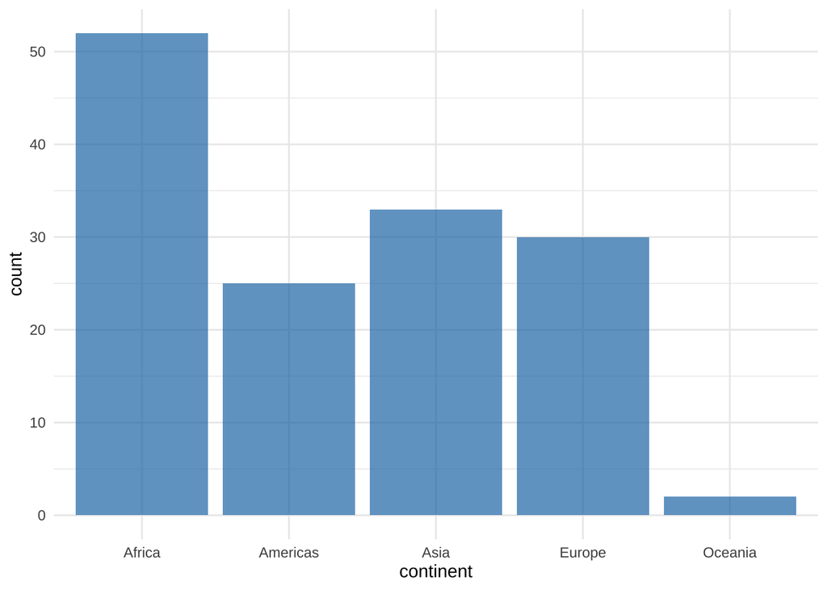

```r
library(tidyverse)
library(gapminder)
library(scales)

df <- gapminder %>% filter(year == 2007)
base_col <- "#1f78b4"

ggplot(df, aes(x = continent)) +
  geom_bar(fill = alpha(base_col, 0.70)) +
  theme_minimal()
```

##### **2）从调色板取色并用于出图（RColorBrewer / ggsci）**

###### **（a）`RColorBrewer`：顺序 / 发散 / 离散色板**

`RColorBrewer` 提供经过广泛使用的配色方案，适合科研图形中的三类需求：  
- **顺序色带**：连续变量（由浅入深表示由小到大）  
- **发散色带**：存在基准值（中心浅色，两端分别表示低于/高于基准）  
- **离散色板**：分类变量（类别区分清晰）

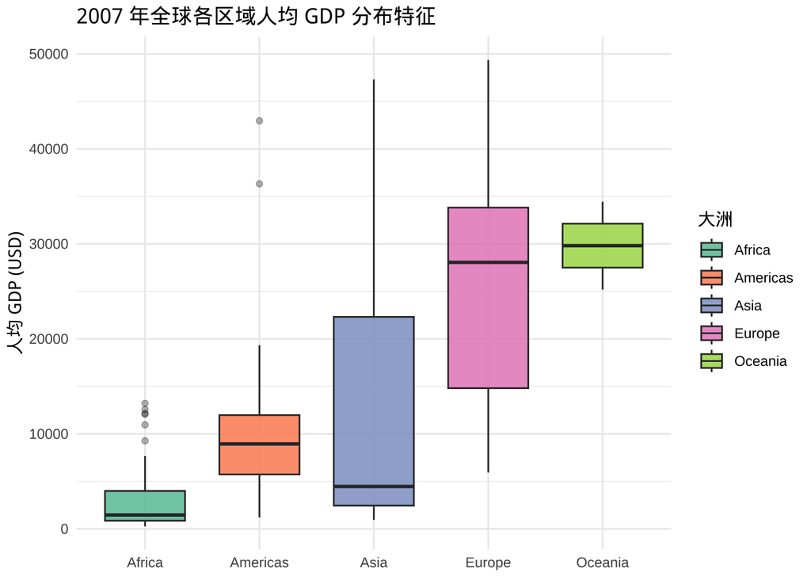

```r
library(tidyverse)
library(gapminder)
library(RColorBrewer)

# 提取 2007 年度全球跨国截面数据
df <- gapminder %>% filter(year == 2007)

# 采用 Set2 离散色板，并将颜色与因子层级(Factor Levels)显式绑定，以确保跨图表视觉映射的一致性
cols <- brewer.pal(n = 5, name = "Set2")
names(cols) <- levels(df$continent)

# 构建统计分布箱线图：实施手动填充映射，并优化离群值(Outliers)与透明度以增强数据可读性
ggplot(df, aes(x = continent, y = gdpPercap, fill = continent)) +
  geom_boxplot(width = 0.7, alpha = 0.85, outlier.alpha = 0.35) +
  scale_fill_manual(values = cols, name = "大洲") +
  labs(
    title = "2007 年全球各区域人均 GDP 分布特征",
    x = NULL, y = "人均 GDP (USD)"
  ) +
  theme_minimal() # 采用极简主题风格，聚焦分布结构主体
```

###### **（b）`ggsci`：期刊风格离散色板**

> `ggsci::pal_xxx()` 一般返回“调色板函数”，再用 (`n`) 取 `n` 个颜色

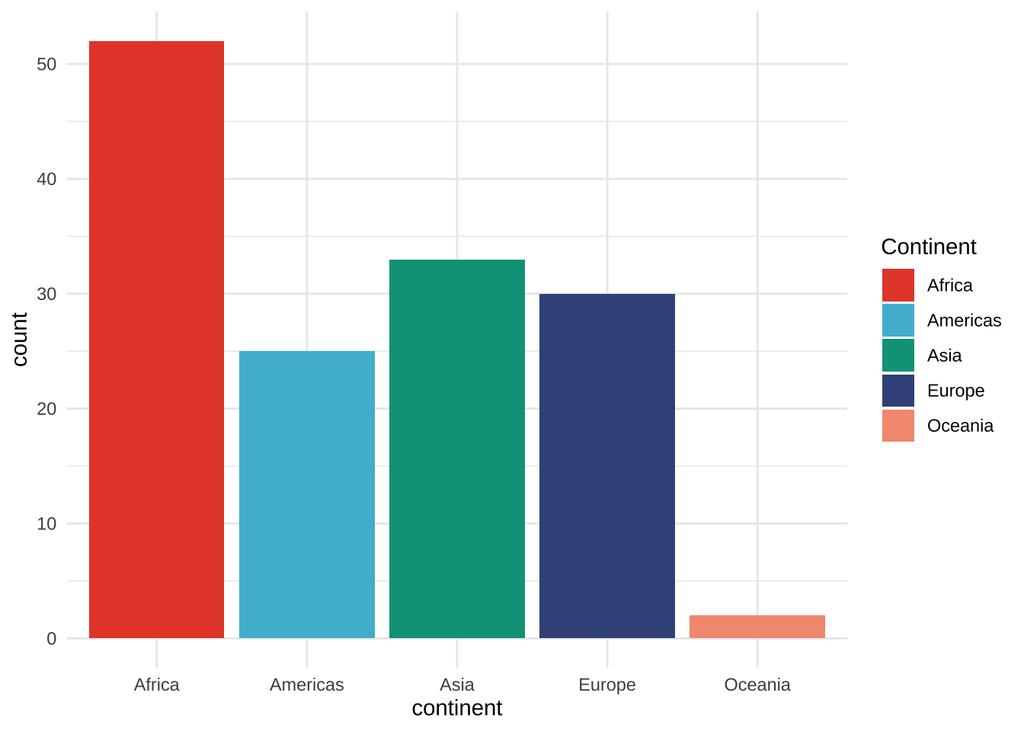

```r
library(tidyverse)
library(gapminder)
library(ggsci)

# 提取 2007 年度全球跨国截面数据，并同步初始化因子能级 (Factor Levels)
df <- gapminder %>%
  filter(year == 2007) %>%
  mutate(continent = factor(continent))

# 确定分类变量的能级总数 (k)，为色盘提取提供参数依据
k <- nlevels(df$continent)

# 调用 ggsci 提供的 Nature Publishing Group (NPG) 学术色盘函数
# 注：根据需求可切换为 pal_aaas() (Science) 或 pal_lancet() (Lancet) 等规范色盘
pal_fun <- ggsci::pal_npg("nrc")
pal     <- pal_fun(k)

# 实施『颜色—类别』显式绑定 (Explicit Binding)，确保多图表呈现时美学特征的绝对一致性
names(pal) <- levels(df$continent)

# 构建频数分布柱状图，并通过手动标度 (Manual Scale) 映射学术级色盘
ggplot(df, aes(x = continent, fill = continent)) +
  geom_bar() +
  scale_fill_manual(values = pal, name = "Continent") +
  theme_minimal() # 采用极简主题，移除视觉冗余以聚焦核心统计信息
```

##### **3）把“网上找到的一套配色”输入到 R 并固定映射**

当从网站（如 Coolors / Adobe Color 等）获得一组 **hex** 颜色时，可直接将其复制为一个向量，并**绑定到类别名**。

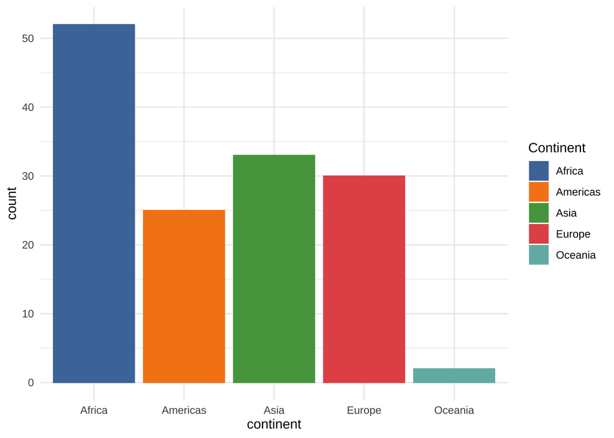

```r
library(tidyverse)
library(gapminder)

# 提取 2007 年度全球跨国截面数据
df <- gapminder %>% filter(year == 2007)

# 预定义十六进制颜色向量，并与大洲类别显式映射，确保视觉编码在全局范围内的一致性
my_cols <- c(
  Africa   = "#4C78A8",
  Americas = "#F58518",
  Asia     = "#54A24B",
  Europe   = "#E45756",
  Oceania  = "#72B7B2"
)

# 构建频数分布柱状图：实施填充 (fill) 与边框 (colour) 的手动映射
# 设置 guide = "none" 以移除冗余的颜色图例，优化图形的信息密度
ggplot(df, aes(x = continent, fill = continent, colour = continent)) +
  geom_bar(linewidth = 0.4) +
  scale_fill_manual(values = my_cols, name = "Continent") +
  scale_colour_manual(values = my_cols, guide = "none") +
  theme_minimal() # 应用极简主义风格，聚焦于统计主体分布
```

**© 华东师范大学 社会发展学院 人口研究所** | [**DAWN 研究组**](https://dawn-ecnu.github.io) | yzliu@soci.ecnu.edu.cn

课程负责人：刘贇喆 本章作者：刘贇喆 | 蒋娴静

最后更新：2026年03月19日 构建环境：R version 4.5.2 (2025-10-31)

[CC BY-NC-SA 4.0](https://creativecommons.org/licenses/by-nc-sa/4.0/deed.zh) 回到顶部

## **6.0 本章练习**

### **6.0 动手实战**

实战目标

本节练习使用 `fivethirtyeight` 包中的 `hate_crimes` 州级数据进行数据可视化分析：  
（1）以 `gini_index` 与 `avg_hatecrimes_per_100k_fbi` 绘制**相关性散点图**（线性回归趋势 + 方程 + 相关系数与 *p* 值）；  
（2）以 `share_vote_trump` 将州划分为“红/蓝州”，比较 `median_house_inc` 的分布差异，绘制**小提琴 + 箱线 + 抖动点**的复合分布图，并进行 **t 检验**（两组均值差异）。

将巩固以下能力：  
- **数据处理**：缺失值处理、分组变量派生（高亮/分组标签）。  
- **图层组织**：趋势层、点/标注层与统计注释层的叠加与遮挡控制。  
- **统计呈现**：回归注释（方程、相关性）与组间检验注释（t 检验）的一体化表达。

#### **6.1 数据与研究问题设定**

**数据来源**：  
`fivethirtyeight::hate_crimes`（州级汇总数据）。  
本节练习在去除缺失值后开展分析（`drop_na()`）。

#### **数据说明：`fivethirtyeight` 与 `hate_crimes`**

- `fivethirtyeight` 是一个用于教学与复现实证分析的 R 数据包，整理并发布了新闻机构 **FiveThirtyEight** 报道中使用的公开数据片段（便于练习数据清洗、可视化与统计建模）。
- `hate_crimes` 为其中的州级数据集，包含与 **仇恨犯罪水平**、**收入与不平等**、以及 **2016 年总统选举投票结构**相关的变量（不同变量用于不同图形任务）。

**研究问题**：

- **研究问题1｜相关性表达**：各州 **贫富差距**（`gini_index`，基尼系数） 与 **仇恨犯罪率**（`avg_hatecrimes_per_100k_fbi`；每 10 万人） 是否呈现线性相关？

  本练习在散点图中叠加线性回归拟合，并以 **DC** 作为示例对象进行高亮标注（单独上色 + 加粗标签）。
- **研究问题2｜组间差异（分布对比）**：按 2016 年总统大选结果将州划分为两组（`share_vote_trump > 0.5` 记为 “Trump Won”，否则为 “Clinton Won”），两组的 **家庭收入中位数**（`median_house_inc`） 是否存在差异？

  本练习使用“小提琴 + 箱线 + 抖动点”的组合呈现分布，并给出 *t* 检验的 *p* 值注释。

> 这是一个“照着做”的练习：先复现图形，再逐行理解每一层图形与每一个统计注释的含义。

**请在你的 R Project 中新建一个 R Markdown 文档：**

- 文件名建议：`Lab3_ggplot_vis.Rmd`
- **核心要求**：
  1. 加载 `fivethirtyeight`、`tidyverse`、`ggpubr`、`showtext`（及 `scales`）（未安装请先安装）
  2. 调用 `hate_crimes` 数据集（`data("hate_crimes")`），并进行缺失值处理（`drop_na()`）
  3. 完成两类可视化任务：
     - **散点图**：`gini_index` × `avg_hatecrimes_per_100k_fbi`，叠加回归线与相关性注释
     - **分布图**：按 `share_vote_trump` 构造分组，对比 `median_house_inc` 的分布并给出 *t* 检验注释
  4. 生成 `html` 输出，并检查图形的基本规范（轴含义/单位、尺度、字体、配色与标注）

##### **6.2 可复现模板**

注意

> 从第三章开始，练习不再提供完整的 `.Rmd` 成品模板。  
> 练习要求是在**自建的 R Markdown 文档**中自行插入代码块并运行（可参考前一章的写法）  
> 如需新建代码块，可直接复制下方“代码框模板”。

````
```{r, message=FALSE, warning=FALSE, echo=TRUE}
... 在这里写 r 语言代码 ...
```
````

研究问题1

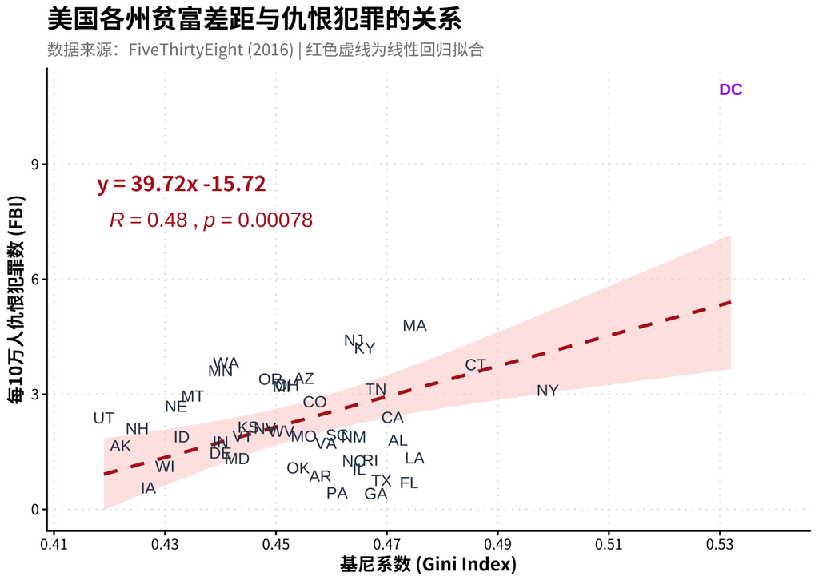

```r
library(fivethirtyeight) # 注意提前安装
library(tidyverse)
library(ggpubr)
library(showtext)
# 提示：在 rmd 中可以通过全局设置读取这些包


# -----------------------------
# 1. 字体设置
# -----------------------------
font_add_google(name = "Noto Sans SC", family = "my_font")
showtext_auto()

# -----------------------------
# 2. 数据准备与处理
# -----------------------------
data("hate_crimes")
df_clean <- hate_crimes %>% drop_na()

# 创建一列用来标记 "是否为DC"，用于后续单独上色
df_clean <- df_clean %>%
  mutate(highlight = if_else(state_abbrev == "DC", "DC", "Normal"))

# -----------------------------
# 3. 计算回归模型 (获取精确系数)
# -----------------------------
model <- lm(avg_hatecrimes_per_100k_fbi ~ gini_index, data = df_clean)
intercept <- coef(model)[1]
slope     <- coef(model)[2]

# 使用 sprintf 自动处理正负号，保留2位小数
# 格式含义：%.2f (2位小数), %+.2f (强制显示正负号)
equation_text <- sprintf("y = %.2fx %+.2f", slope, intercept)

# -----------------------------
# 4. 绘图
# -----------------------------
ggplot(df_clean, aes(x = gini_index, y = avg_hatecrimes_per_100k_fbi)) +

  # --- 趋势线层 (放在最底层，不遮挡文字) ---
  geom_smooth(method = "lm",
              linetype = "dashed",   # 回归线 虚线
              color = "firebrick",   # 回归线 砖红色
              fill = "#ffcccc",      # 回归线 浅粉色
              alpha = 0.5,           # 透明度 50%
              se = TRUE) +

  # --- 文字散点层 ---
  geom_text(aes(label = state_abbrev,
                color = highlight,    # 根据是否为DC变色
                fontface = ifelse(highlight == "DC", "bold", "plain")), # DC加粗
            size = 3.5,
            check_overlap = FALSE) +  # 允许重叠以显示所有州

  # --- 统计指标层 ---

  # 1. 手动添加方程 (使用计算好的 equation_text)
  annotate("text", x = 0.433, y = 8.5,        # 调整位置到左上空白处
           label = equation_text,
           color = "firebrick", family = "my_font", size = 4.5, fontface = "bold") +

  # 2. 自动添加 R 和 P值
  stat_cor(aes(label = paste(after_stat(r.label), after_stat(p.label), sep = "~`,`~")),
           label.x = 0.42, label.y = 7.5,   # 调整位置到左上空白处
           color = "firebrick",
           digits = 2,
           size = 4.5) +

  # --- 装饰与标度 ---
  # 手动设置颜色：DC用紫色，普通州用深灰；比如研究中要重点讨论 DC
  scale_color_manual(values = c("DC" = "purple", "Normal" = "#2c3e50")) +

  scale_x_continuous(limits = c(0.415, 0.54), breaks = seq(0.41, 0.54, 0.02)) +

  labs(title = "美国各州贫富差距与仇恨犯罪的关系",
       subtitle = "数据来源：FiveThirtyEight (2016) | 红色虚线为线性回归拟合",
       x = "基尼系数 (Gini Index)",
       y = "每10万人仇恨犯罪数 (FBI)") +

  # --- 主题设置 ---
  theme_classic() +
  theme(
    # 字体设置
    text = element_text(family = "my_font"),
    plot.title    = element_text(face = "bold", size = 16),
    plot.subtitle = element_text(size = 10, color = "grey50"),
    axis.title    = element_text(face = "bold"),

    # 增加网格线
    panel.grid.major = element_line(color = "grey90", linetype = "dotted"),
    panel.grid.minor = element_blank(),

    # 去掉图例
    legend.position = "none"
  )
```

研究问题2

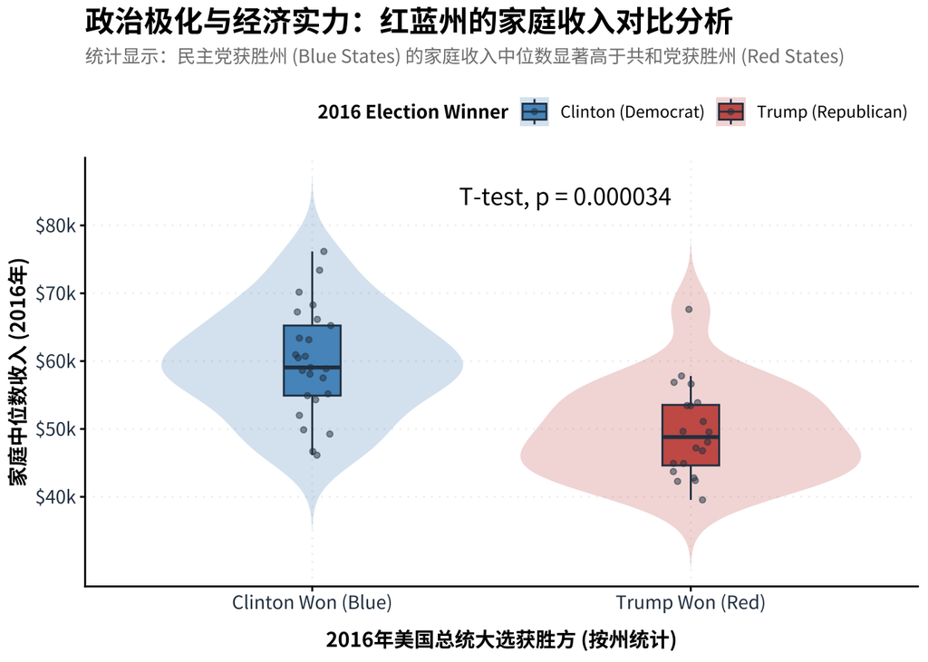

```r
library(fivethirtyeight)
library(tidyverse)
library(ggpubr)
library(showtext)
library(scales)

# ------------------------------------------------------------------------------
# 1. 绘图环境初始化：全局字体渲染配置
# ------------------------------------------------------------------------------
font_add_google(name = "Noto Sans SC", family = "my_font")
showtext_auto()

# ------------------------------------------------------------------------------
# 2. 数据预处理：截面数据清洗与逻辑分组映射
# ------------------------------------------------------------------------------
data("hate_crimes")

# 剔除缺失观测值，并基于 2016 年大选投票份额构建二分名义变量
df_pol <- hate_crimes %>%
  drop_na() %>%
  mutate(
    pol_group = if_else(share_vote_trump > 0.5,
                        "Trump Won (Red)",
                        "Clinton Won (Blue)")
  )

# ------------------------------------------------------------------------------
# 3. 统计图形构建：分层美学映射与假设检验
# ------------------------------------------------------------------------------
ggplot(df_pol, aes(x = pol_group, y = median_house_inc, fill = pol_group)) +

  # A. 分布形态层：通过小提琴图呈现连续变量的核密度估计 (KDE)
  geom_violin(alpha = 0.2, color = NA, trim = FALSE) +

  # B. 统计概括层：嵌套箱线图以展示中位数、四分位区间及统计分布中心
  # 压缩宽度以实现与小提琴图的嵌套平衡，隐藏离群值避免与后续散点层冲突
  geom_boxplot(width = 0.15, color = "#2c3e50", outlier.shape = NA, alpha = 0.8) +

  # C. 原始观测层：引入抖动散点以揭示底层数据颗粒度与异质性
  geom_jitter(width = 0.05, size = 1.2, color = "#2c3e50", alpha = 0.5) +

  # D. 假设检验层：执行独立双样本 T 检验，量化组间差异的显著性水平
  stat_compare_means(method = "t.test",
                      aes(label = paste0("T-test, p = ", ..p.format..)),
                      label.x = 1.5,
                      label.y = 83000,
                      family = "my_font", size = 4.5) +

  # E. 美学标度：基于政治语义的手动配色方案
  scale_fill_manual(
    name = "2016 Election Winner",
    values = c("Trump Won (Red)" = "#C0392B",
               "Clinton Won (Blue)" = "#2980B9"),
    labels = c("Clinton (Democrat)", "Trump (Republican)")
  ) +

  # F. 坐标轴格式化：对 Y 轴执行货币化转换，增强数值传达的直观性
  scale_y_continuous(labels = scales::dollar_format(scale = 1/1000, suffix = "k"),
                     breaks = seq(40000, 80000, 10000)) +

  # G. 标签层：定义学术级标题与描述性说明
  labs(title = "政治极化与经济实力：红蓝州的家庭收入对比分析",
       subtitle = "统计显示：民主党获胜州 (Blue States) 的家庭收入中位数显著高于共和党获胜州 (Red States)",
       x = "2016年美国总统大选获胜方 (按州统计)",
       y = "家庭中位数收入 (2016年)") +

  # H. 主题定制：优化视觉密度与信息层级
  theme_classic() +
  theme(
    text = element_text(family = "my_font"),
    plot.title    = element_text(face = "bold", size = 16),
    plot.subtitle = element_text(size = 10, color = "grey50", margin = margin(b = 10)),

    # 坐标轴与文字微调：强化标题辨识度
    axis.title.x  = element_text(face = "bold", size = 11, margin = margin(t = 10)),
    axis.title.y  = element_text(face = "bold", size = 11),
    axis.text     = element_text(size = 10, color = "#2c3e50"),

    # 网格线配置：保留辅助性纵向/横向参考线以辅助跨组数值比对
    panel.grid.major.y = element_line(color = "grey95", linetype = "dotted"),
    panel.grid.major.x = element_line(color = "grey95", linetype = "dotted"),

    # 图例排版：采用顶部右对齐布局，提升绘图核心区域的空间利用率
    legend.position = "top",
    legend.justification = "right",
    legend.title = element_text(face = "bold", size = 10),
    legend.background = element_rect(fill = "transparent")
  )
```

##### **6.3 进阶代码挑战**

进阶练习

本节不提供参考代码。任务目标是：使用 `gapminder` 的时序数据，独立完成一组**可用于报告/论文**的“研究级可视化”，重点训练 **分布 × 时间 × 分组** 的综合表达能力。

###### **6.3.1 数据与研究问题**

**数据集**：`gapminder`（国家 × 年份的面板数据）  
**核心变量（建议）**：  
- 分布变量：`lifeExp` 或 `gdpPercap`  
- 分组变量：`continent`  
- 时间变量：`year`

**研究问题**：  
- 不同大洲在 1952–2007 年间，某项指标（`lifeExp` 或 `gdpPercap`）的**分布形态**如何随时间演变？  
- 分布的**中位数水平**、**离散程度（IQR）**与**离群值**是否呈现系统性变化？

###### **6.3.2 可视化任务**

**任务 A｜时序箱线图**  
绘制“按年份排列的箱线图序列”：  
- **横轴**：`year`（建议转换为因子，以确保每一年都有一个箱线图）  
- **纵轴**：`lifeExp` 或 `gdpPercap`  
- **分面**：按 `continent` 分面（`facet_wrap(~ continent, ncol = 1)` 或 `facet_grid(continent ~ .)`）  
- **要求**：每一个年份对应一个箱线图；每个箱线图内部包含该大洲当年所有国家的观测值。

**任务 B｜配色与美化**  
- 选择合理配色方案并说明理由：  
- 若使用离散配色（按大洲），需保持跨图一致。  
- 若 `year` 为因子且颜色映射到 `continent`，应避免图例冗余（可视情况关闭图例）。  
- 处理可读性问题：年份多、刻度密集时，需通过字号、角度、留白或抽样刻度提升可读性。  
- 图形需包含：标题、简洁副标题、轴含义与单位说明（如有变换需标注）。

###### **6.3.3 技术要求**

- 使用 **R Markdown** 完成，并 `knit` 输出为 **HTML**。
- 文档需包含：
  1. 数据准备（筛选/变换/缺失值处理，如有）
  2. 作图代码（结构清晰、分段注释）
  3. 简短文字解读（2–4 句）：描述最明显的分布差异与时间变化
- 代码注释要求：
  - 说明关键选择：变量为何选 `lifeExp` 或 `gdpPercap`；为何采用该分面方式；配色为何合理。

#### **提示**

- `year` 若保持数值型，箱线图会在连续轴上挤在一起；将其转为因子通常更稳健。
- 若选择 `gdpPercap`，可考虑对数变换以缓解长尾分布（变换必须在轴标签中说明）。
- 年份刻度过密时，可只显示每隔若干年的标签，或旋转 x 轴文字提升可读性。

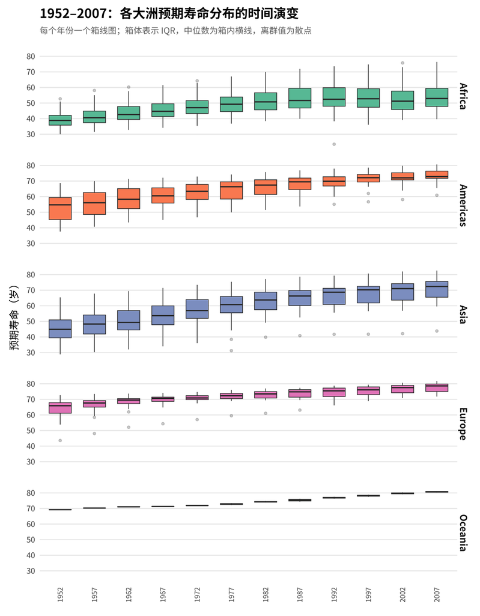

输出参考

**© 华东师范大学 社会发展学院 人口研究所** | [**DAWN 研究组**](https://dawn-ecnu.github.io) | yzliu@soci.ecnu.edu.cn

课程负责人：刘贇喆 本章作者：刘贇喆 | 蒋娴静

最后更新：2026年03月19日 构建环境：R version 4.5.2 (2025-10-31)

[CC BY-NC-SA 4.0](https://creativecommons.org/licenses/by-nc-sa/4.0/deed.zh) 回到顶部